# Final_project_work3

Ninna Nataly Iriondo Castro Friis

2022-12-12

#The scrips is inspired by the script “Game Of Thrones” from the class https://github.com/Ninnanataly/AU689876/blob/main/GoT_analyse.Rmd #I load the different library packages, so I can use the tools

```r
library(tidyverse)
library(here)
library(dplyr)
library(tidytext)
library(pdftools)
library(readxl)
```

#I make a vector with list of the dataset from 1371-1400 and name it “filnavne”

```r
list.files("Data_1371_1400", full.names = TRUE) -> filnavne
```

#Combine the dataset from 1371 to 1998, because the dataset from 1999-1400 do not contain the letters that I can use, I will not combine it - The name will still be 1371-1400, because it does it a lot easier

```r
DRB_1371_1400 <- tibble()
tmp_df <- tibble()
fil <- c()
for (fil in filnavne){
  print(fil)
  tmp_df <- read_excel(fil)
  tmp_df <- tmp_df %>%
    mutate(Nummer= as.numeric(Nummer))
  DRB_1371_1400 <- bind_rows(DRB_1371_1400, tmp_df)
}
```

```
## [1] "Data_1371_1400/Datasæt_DRB-1371-1375.xlsx"
## [1] "Data_1371_1400/Datasæt_DRB-1376-1379.xlsx"
## [1] "Data_1371_1400/Datasæt_DRB-1380-1385.xlsx"
```

```
## [1] "Data_1371_1400/Datasæt_DRB-1386-1388.xlsx"
## [1] "Data_1371_1400/Datasæt_DRB-1389-1392.xlsx"
## [1] "Data_1371_1400/Datasæt_DRB-1393-1395.xlsx"
## [1] "Data_1371_1400/Datasæt_DRB-1396-1398.xlsx"
```

#Convert the raw dataset from excel fil to csv and import to Jupyter Lab to extract the names

```r
DRB_1367_1370.csv <- read_csv2("Data_1367_1370/Datasæt_DRB_1367_1370.xlsx")
```

```
## ℹ Using "','" as decimal and "'.'" as grouping mark. Use `read_delim()` for more control.
```

```
## Multiple files in zip: reading '[Content_Types].xml'
##
```

#Read the 1367-1370_name csv files in R, which is importet from Jupyter Lab

```r
DRB_1367_1370_name <- read_csv2("Data/DRB_1367_1370_name.csv")
```

```
## ℹ Using "','" as decimal and "'.'" as grouping mark. Use `read_delim()` for more control.
```

#split the column “,doc_id,name” to 3 seperated columns and i found the function in this link: http://web.archive.org/web/20230106123427/https://www.rdocumentation.org/packages/stringr/versions/0.6.2/topics/str_split_fixed

```r
DRB_1367_1370_name[c('number', 'doc_id', 'name')] <- str_split_fixed(DRB_1367_1370_name$",doc_id,name", ',', 3)
```

#Split the text in the column “name” into words using to tokens function

```r
DRB_tokens1 <- DRB_1367_1370_name %>%
  unnest_tokens(word, ",doc_id,name")
```

#Create a stopwordlist and make it a dataframe

```r
stop_words1 <- tibble(word=c("Gud","Guds","Margrete","Valdemar","Eder","'","Eders","eder","eders","margrete","margretes","valdemar","gud","guds", "oluf","v","van","Erik","erik"))
```

#Remove the stopwordlist from the wordlist “DRB_tokens1”

```r
DRB_stop1 <- DRB_tokens1 %>%
  anti_join(stop_words1)
```

#count the names and look which 10 names occur most often

```r
DRB_1367_1370_names_count <- DRB_stop1 %>%
  count(word, sort = TRUE) %>%
  head(10)
```

#rename the column “word” to “name”

```r
names(DRB_1367_1370_names_count)[names(DRB_1367_1370_names_count)=="word"] <- "name"
```

#Put the 10 names into a ggplot with geom columns, reorder it and color it and i got the funcktion from this link: http://web.archive.org/web/20230106123720/http://www.sthda.com/english/wiki/ggplot2-colors-how-to-change-colors-automatically-and-manually

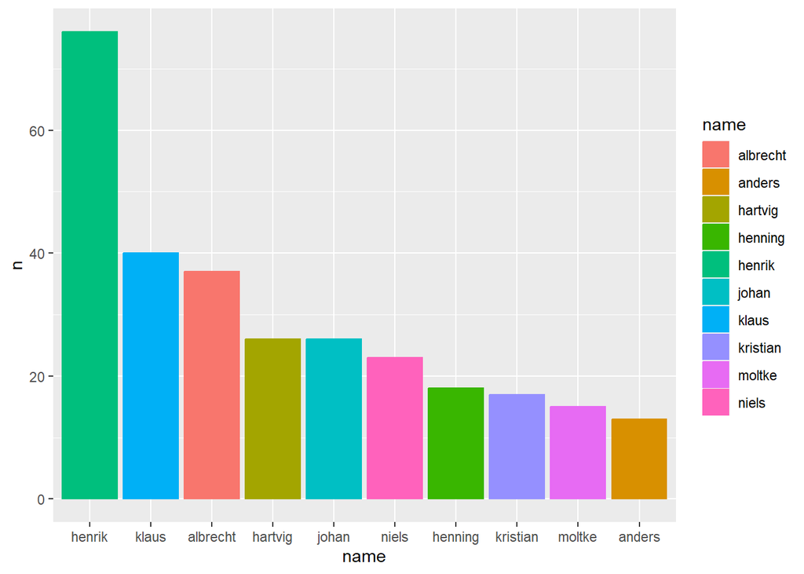

```r
ggplot(data = DRB_1367_1370_names_count, aes(x = reorder(name, -n), y = n, color=name, fill=name))+
  geom_col() +
  labs(x="name")
```

#Read the csv file from 1371_1400_name from Jupyter Lab into R

```r
DRB_1371_1400_names <- read.csv("Data/DRB_1371_1400_name.csv")
```

#split the text in the column “name” into words

```r
DRB_tokens2 <- DRB_1371_1400_names %>%
  unnest_tokens(word, name)
```

#I use the same stopwordlist

#remove the stopwordlist from the wordlist “DRB_tokens2”

```r
DRB_stop2 <- DRB_tokens2 %>%
  anti_join(stop_words1)
```

#count the names and look which 10 names occur most often

```r
DRB_1371_1400_names_count <- DRB_stop2 %>%
  count(word, sort = TRUE) %>%
  head(10)
```

#rename the column “word” to “name”

```r
names(DRB_1371_1400_names_count)[names(DRB_1371_1400_names_count)=="word"] <- "name"
```

#Put the 10 names into a ggplot with geom columns, color it and reorder it and i got the funcktion from this link: http://web.archive.org/web/20230106123720/http://www.sthda.com/english/wiki/ggplot2-colors-how-to-change-colors-automatically-and-manually

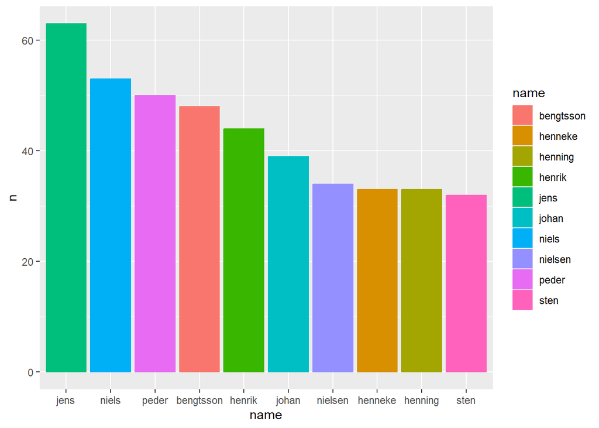

```r
ggplot(data = DRB_1371_1400_names_count, aes(x = reorder(name, -n), y = n, color=name, fill=name))+
  geom_col() +
  labs(x="name")
```